# Text Analytics (MLDS 414)

# Fitting Naive Bayes Models

### Yuri Balasanov, Mikhail Tselishchev, © iLykei 2023-2024

## Sentiment Analysis or Opinion Mining

Explosion in communications through social media brought sentiment analysis in the forefront big data analysis problems. What is sentiment?

Sentiment by definition is very subjective: it is based on feelings, emotions, personal opinions, rather than facts. Sentiment is also usually expressed in a very individual ways: jargon, sarcasm, humor, irony, contradictions. Sentiment is actively exchanged between members of society, it is quickly changing, highly influenced by others. In the process of spreading and exchanging sentiments society as a whole generates important opinions.

Use of opinion mining:

- A company detects success of a product or marketing campaign;
- A political scientist finds out about reaction of the society to certain events, dynamics of approval of political candidates, society consensus points;
- A consumer finds the product of best qualities, events that are worth or not worth attending.

Special features of opinion mining:

- Sentiment usually has a few categories (positive, neutral, negative)
- Sentiments are distributed across different contexts, topics
- Sentiments are frequently subconscious, not clearly expressed or mixed with opinions on other topics
- Popular topics are frequently changing, opinions collected from multiple sources in different forms, amount of information is tremendous
- Complexity of analysis requires very sophisticated models.

Look at [this](http://text-processing.com/demo/sentiment/) real time sentiment analysis web site. Try to submit there a few reviews. For example, use these reviews of classical books.

**"Ulysses" by James Joyce** This is a tough book to read unless you understand several languages and are on LSD. I may have thirty or forty more years to live so maybe I’ll get through it.

**"The Grapes of Wrath" by John Steinbeck** This book was rather long and boring then adventurous and fun. I have read many books written by John Steinbeck such as: The Red Pony, Of Mice and Men and etc. If you want to read this book then go ahead but I would rather recommend Of Mice and Men or The Red Pony.

Or [this collection of reviews](http://lct-master.org/files/MullenSentimentCourseSlides.pdf) which shows how difficult it is to extract the right sentiment from a text:

**(five star)** "The characters are so real and handled so carefully, that being trapped inside the Overlook is no longer just a freaky experience. You run along with them, filled with dread, from all the horrible personifications of evil inside the hotel’s awful walls. There were several times where I actually dropped the book and was too scared to pick it back up. Intellectually, you know it’s not real. It’s just a bunch of letters and words grouped together on pages. Still, whenever I go into the bathroom late at night, I have to pull back the shower curtain just to make sure."

**(one star)** "The original Star Wars trilogy was a defining part of my childhood. Born as I was in 1971, I was just the right age to fall headlong into this amazing new world Lucas created. I was one of those kids that showed up early at toy stores […] anxiously awaiting each subsequent installment of the series. I’m so glad that by my late 20s, the old thrill had faded, or else I would have been EXTREMELY upset over Episode I: The Phantom Menace … perhaps the biggest let-down in film history."

**(0/10)** "Ten years on from Exile, Liz has finally managed to achieve what seems to have been her goal ever since the possibility of commercial success first presented itself to her: to release an album that could have just as easily been made by anybody else."

**(1 star)** "It took a couple of goes to get into it, but once the story hooked me, I found it difficult to put the book down – except for those moments when I had to stop and shriek at my friends,"SPARKLY VAMPIRES!" or "VAMPIRE BASEBALL!" or "WHY IS BELLA SO STUPID?" These moments came increasingly often as I reached the climactic chapters, until I simply reached the point where I had to stop and flail around laughing."

## Data

Data for this project are in the form of a corpus of documents.  
Each document is a tweet regarding an airline service.  
The goal is to identify (predict) the sentiment of the document: +1 for positive, 0 - for neutral and -1 - for negative.  
The training set contains the sentiment column in which allocation of sentiments was done by humans.  
Vocabulary for this project will be created from the table of all words in the corpus of documents.

**Disclaimer**. Texts used in this project are real tweets from Airline Twitter sentiment data downloaded here. As a typical real life language sample, these texts contained certain amount of profanity showing strong and genuine feelings of their authors. Team iLykei made their best effort removing such subset of language in spite of inevitable loss of expressive color associated with language censorship. However, it is possible that our profanity lexicon is not rich enough to search for all creative expressions that might be in use among the tweeting community. If you notice any terms that should be removed, please, let us know.

```python
import re
from joblib import dump, load

import numpy as np
import pandas as pd
import nltk
import matplotlib.pyplot as plt
from sklearn.model_selection import train_test_split
from sklearn.feature_extraction.text import CountVectorizer
from sklearn.naive_bayes import BernoulliNB, MultinomialNB
from sklearn.metrics import log_loss
```

Read the train data file:

```python
df = pd.read_csv('data/air_tweet_train.csv', names=['Sentiment', 'Tweet'])
df
```

|  | Sentiment | Tweet |
| --- | --- | --- |
| 0 | -1 | @SouthwestAir good thing we noticed because sh... |
| 1 | 1 | @united They let us know in advance of the reb... |
| 2 | -1 | @USAirways sucks. Delayed my mom's flight 2X, ... |
| 3 | -1 | @united can you DM me? Been on hold with custo... |
| 4 | 1 | @AmericanAir THANK YOU FOR ALL THE HELP! :P Y... |
| ... | ... | ... |
| 13874 | 0 | @JetBlue with 3 kids and 11 days 340 + doesn't... |
| 13875 | 1 | @AmericanAir LTALJX, from DCA to OMA this morn... |
| 13876 | -1 | @AmericanAir I can't work with them if the cal... |
| 13877 | -1 | @AmericanAir 2 months and still no exec platin... |
| 13878 | -1 | @united quality work going on here. http://t.c... |

13879 rows × 2 columns

Check the distribution of sentiments.

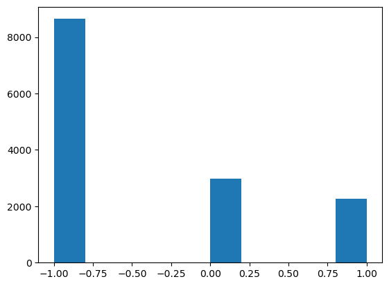

```python
plt.hist(df.Sentiment);
```

To prepare the data for fitting the binomial naive Bayes model (Bernoulli) follow these steps:

- From each tweet remove all non-letter symbols.
- Do case folding to lower case.
- Tokenize the tweets using `nltk.word_tokenize()`.
- Use the NLTK modules with stopwords and punctuation to remove unnecessary words from the corpus. Add to the list of the removed tokens some specific terms for this corpus, like airline companies' names, words like "fly", "flying", "flight', "flights", "plane", etc.
- Tokenize each tweet using `nltk.word_tokenize()`.
- Create the lemmatizer based on WordNet in NLTK. Use it to lemmatize all documents.
- Combine all these steps in one function `my_tokenizer(tweet)`. Test the function.
- Apply `my_tokenizer(tweet)` to all tweets.
- Convert a collection of text documents to a matrix of binary token counts `matrix_bernoulli`, using `CountVectorizer` from `sklearn`. Number of rows of `matrix_bernoulli` equals to the number of tweets, number of columns is equal to number of different tokens in the vocabulary.

```python
vectorizer_bernoulli = load('models/vectorizer_bernoulli.joblib')
```

```python
matrix_bernoulli = load('models/matrix_bernoulli.joblib')
```

```python
df = load('models/df.joblib')
df
```

|  | Sentiment | Tweet | Tokens |
| --- | --- | --- | --- |
| 0 | -1 | @SouthwestAir good thing we noticed because sh... | good thing noticed routed total passenger impo... |
| 1 | 1 | @united They let us know in advance of the reb... | let u know advance reboot yes thanks attentive... |
| 2 | -1 | @USAirways sucks. Delayed my mom's flight 2X, ... | suck delayed mom x cancelled flightled delayed... |
| 3 | -1 | @united can you DM me? Been on hold with custo... | dm hold customer service long time min getting... |
| 4 | 1 | @AmericanAir THANK YOU FOR ALL THE HELP! :P Y... | thank help p guy best americanairlines |
| ... | ... | ... | ... |
| 13874 | 0 | @JetBlue with 3 kids and 11 days 340 + doesn't... | kid day work month advance |
| 13875 | 1 | @AmericanAir LTALJX, from DCA to OMA this morn... | ltaljx dca oma morning staff helped fix proble... |
| 13876 | -1 | @AmericanAir I can't work with them if the cal... | work call get cut still holding dfw looking be... |
| 13877 | -1 | @AmericanAir 2 months and still no exec platin... | month still exec platinum member card give |
| 13878 | -1 | @united quality work going on here. http://t.c... | quality work going http co xbo dakak |

13879 rows × 3 columns

Check the shape of the matrix `matrix_bernoulli`.

```python
matrix_bernoulli.shape
```

```
(13879, 12125)
```

This is a really sparse matrix!

```python
(matrix_bernoulli == 0).mean()
```

```
0.999322997066695
```

The matrix is binary, i.e. word counts in each document can be either zero (not present) or 1 (present).

```python
print('Unique values in matrix_bernoulli: ',np.unique(matrix_bernoulli))
```

```
Unique values in matrix_bernoulli:  [0 1]
```

## Fitting the model

Separate train and test data.

```python
x_bern_train, x_bern_test, y_train, y_test \
    = train_test_split(matrix_bernoulli, df['Sentiment'].values,
                       test_size = 0.2, random_state = 42)
```

Fit binomial naive Bayes model.  
Print the scores.

```python
nb_bernoulli = BernoulliNB()
nb_bernoulli.fit(x_bern_train, y_train)
print(f'{nb_bernoulli.score(x_bern_test, y_test)=}')
```

```
nb_bernoulli.score(x_bern_test, y_test)=0.7280259365994236
```

Predict sentiment using binomial model.

```python
bern_proba = nb_bernoulli.predict_proba(x_bern_test)
bern_proba
```

```
array([[8.26496857e-01, 1.27254514e-01, 4.62486294e-02],
       [9.94298368e-01, 5.68934683e-03, 1.22851758e-05],
       [9.99326464e-01, 1.14322211e-04, 5.59213639e-04],
       ...,
       [8.58641681e-01, 1.37462718e-01, 3.89560111e-03],
       [9.99996928e-01, 2.79726085e-06, 2.74637559e-07],
       [9.99964067e-01, 1.02686994e-05, 2.56645458e-05]])
```

Calculate and print logloss of the model.

```python
bern_proba /= bern_proba.sum(axis=1)[..., np.newaxis]
print(f'{log_loss(y_test, bern_proba)=}')
```

```
log_loss(y_test, bern_proba)=0.853905780204279
```

Now train on the whole dataset and save the model for use in the event handler.

```python
y = df['Sentiment'].values

nb_bernoulli = BernoulliNB()
nb_bernoulli.fit(matrix_bernoulli, y)
```

```
BernoulliNB()
```

```python
dump(nb_bernoulli, 'models/nb_bernoulli.joblib')
```

```
['models/nb_bernoulli.joblib']
```

```python
dump(vectorizer_bernoulli, 'models/vectorizer_bernoulli.joblib')
```

```
['models/vectorizer_bernoulli.joblib']
```